# Part II - Bay Wheels Bike Sharing System Usage Pattern 2018

## by Michelle Bleyl

## Investigation Overview

> Bay Wheels (Ford GoBike System Data) stores information about individual rides made in a bike-sharing system covering the greater San Francisco Bay area. It's bike sharing rental service company with nearly 500,000 rides since the launch in 2017 and had about 10,000 annual subscribers in January 2018. The dataset is used for exploratory analysis that includes daily usage time and information about the customers.

## Dataset Overview

> The dataset used for exploratory analysis purposes. The datasets consists of bike sharing system in San Francisco Bay area information such that it consists data of stations, members, what time they travel, what day of week they travel, how long their trip was etc. Visualizations are created below with much more cleaned data than part_I to facilitate exploration analysis and help discover usage pattern/habits.

## Population of User Type and Their Weekly Usage

> The majority riders are subscribers which they have a usage of 90.7%, while customers have 9.3%. Subscribers are likely to ride during weekdays, Monday to Friday.However, Customers ride don't have a siginificant difference between weekday and weekends. This indicates that subscribers are more likely o=to ride during work day and casual customers are more likely to use for fun or trip.

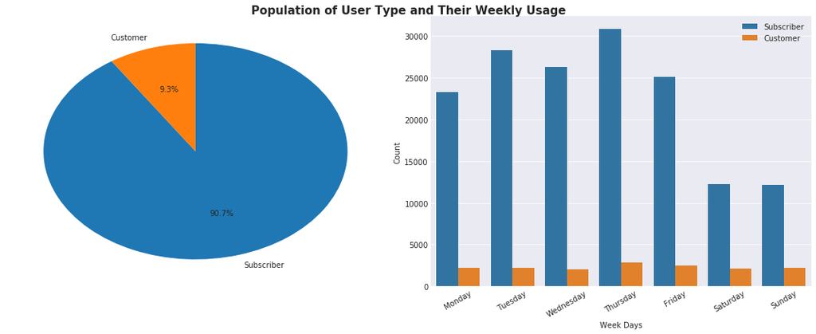

## Hourly Usage during Weekdays for Customers and Subscribers

> Different usage patterns/habits between subscribers and customers. Subscribers rides heavily on work days, whereas customers ride a lot on weekends, especially in the afternoon. Many trips concentrated around 7-9am and 4-6pm on work days for subscribers. This indicates that they use it for commuting to work. On the other hand, customershave a different usage purpose such that they use on afternoon during weekends and on rush hours during weekdays. This indicates that customers are not using just for communing to work purposes but also for adventures/luxurious purposes.

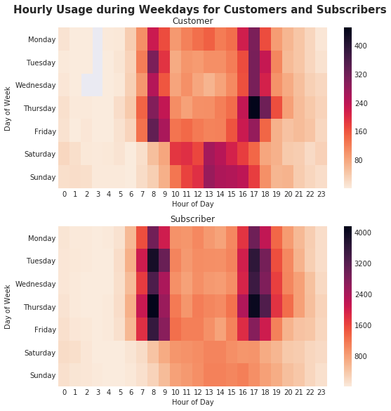

## Gender Usage Difference in Weeks and Hour of the Day

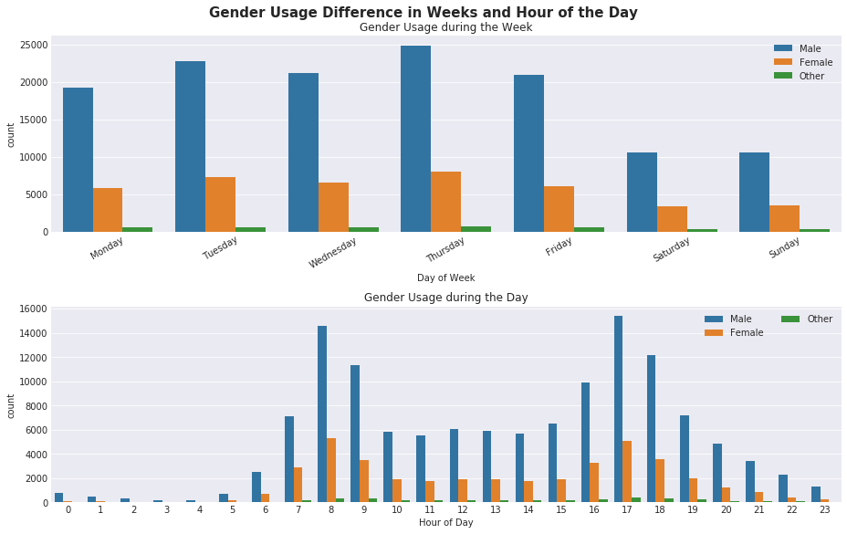